# Post-fitting inference, etc. with glmmTMB models

2019-01-11

The purpose of this vignette is to describe (and test) the functions in various downstream packages that are available for summarizing and otherwise interpreting `glmmTMB` fits. Some of the packages/functions discussed below may not be suitable for inference on parameters of the zero-inflation or dispersion models, but will be restricted to the conditional-mean model.

```r
library(glmmTMB)
library(car)
library(emmeans)
library(effects)
library(multcomp)
library(MuMIn)
library(DHARMa)
## library(broom)
## library(broom.mixed)
library(dotwhisker)
library(ggplot2); theme_set(theme_bw())
## retrieve slow stuff
L <- load(system.file("vignette_data","model_evaluation.rda",package="glmmTMB"))
```

A couple of example models:

```r
owls_nb1 <- glmmTMB(SiblingNegotiation ~ FoodTreatment*SexParent +
                        (1|Nest)+offset(log(BroodSize)),
                    contrasts=list(FoodTreatment="contr.sum",
                                   SexParent="contr.sum"),
                    family = nbinom1,
                    zi = ~1, data=Owls)
```

```r
data("cbpp",package="lme4")
cbpp_b1 <- glmmTMB(incidence/size~period+(1|herd),
                   weights=size,family=binomial,
                   data=cbpp)
## simulated three-term Beta example
set.seed(1001)
dd <- data.frame(z=rbeta(1000,shape1=2,shape2=3),
                 a=rnorm(1000),b=rnorm(1000),c=rnorm(1000))
simex_b1 <- glmmTMB(z~a*b*c,family=beta_family,data=dd)
```

## model checking and diagnostics

### DHARMa

The `DHARMa` package provides diagnostics for hierarchical models.

After running

```r
owls_nb1_simres <- simulateResiduals(owls_nb1)
```

```r
system.time(sr <- simulateResiduals(owls_nb1))
```

```
##    user  system elapsed
##  10.138   0.054  10.239
```

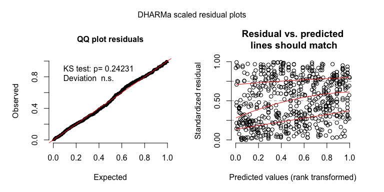

```r
plot(sr)
```

## Inference

### car::Anova

We can use `car::Anova()` to get traditional ANOVA-style tables from `glmmTMB` fits. A few limitations/reminders:

- these tables are using Wald $\chi^2$ statistics for comparisons (neither likelihood ratio tests nor $F$ tests)
- they apply to the fixed effects of the conditional component of the model only (other components *might* work, but haven’t been tested at all)
- as always, if you want to do type 3 tests, you should probably set sum-to-zero contrasts on factors and center numerical covariates (see `contrasts` argument above)

```r
Anova(owls_nb1)  ## default type II
```

```
## Analysis of Deviance Table (Type II Wald chisquare tests)
##
## Response: SiblingNegotiation
##                          Chisq Df Pr(>Chisq)
## FoodTreatment           44.174  1  3.004e-11 ***
## SexParent                0.032  1     0.8581
## FoodTreatment:SexParent  2.290  1     0.1302
## ---
## Signif. codes:  0 '***' 0.001 '**' 0.01 '*' 0.05 '.' 0.1 ' ' 1
```

```r
Anova(owls_nb1,type="III")
```

```
## Analysis of Deviance Table (Type III Wald chisquare tests)
##
## Response: SiblingNegotiation
##                           Chisq Df Pr(>Chisq)
## (Intercept)             21.4354  1   3.66e-06 ***
## FoodTreatment           46.1411  1   1.10e-11 ***
## SexParent                0.5117  1     0.4744
## FoodTreatment:SexParent  2.2900  1     0.1302
## ---
## Signif. codes:  0 '***' 0.001 '**' 0.01 '*' 0.05 '.' 0.1 ' ' 1
```

### effects

```r
(ae <- allEffects(owls_nb1))
```

```
##  model: SiblingNegotiation ~ FoodTreatment * SexParent + offset(log(BroodSize))
##
##  FoodTreatment*SexParent effect
##
## offset =  1.439028
##
##              SexParent
## FoodTreatment   Female     Male
##      Deprived 9.607085 8.961150
##      Satiated 4.070916 4.986572
```

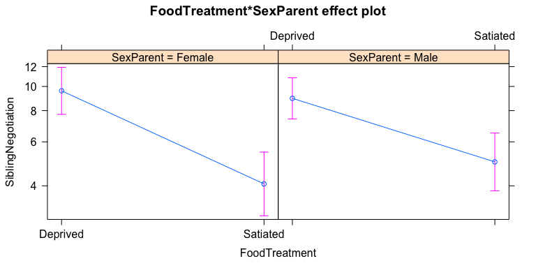

```r
plot(ae)
```

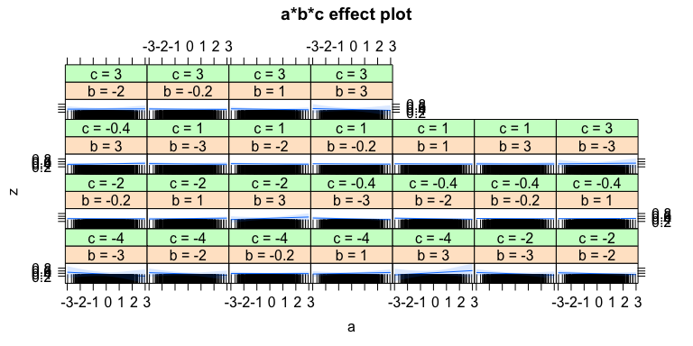

```r
plot(allEffects(simex_b1))
```

### emmeans

```r
emmeans(owls_nb1, poly ~ FoodTreatment | SexParent)
```

```
## $emmeans
## SexParent = Female:
##  FoodTreatment   emmean         SE  df lower.CL upper.CL
##  Deprived      2.303330 0.11042823 592 2.086451 2.520209
##  Satiated      1.444697 0.14934877 592 1.151379 1.738015
##
## SexParent = Male:
##  FoodTreatment   emmean         SE  df lower.CL upper.CL
##  Deprived      2.233728 0.09636776 592 2.044463 2.422992
##  Satiated      1.647578 0.13567734 592 1.381110 1.914045
##
## Results are given on the log (not the response) scale.
## Confidence level used: 0.95
##
## $contrasts
## SexParent = Female:
##  contrast   estimate        SE  df t.ratio p.value
##  linear   -0.8586328 0.1486427 592  -5.776  <.0001
##
## SexParent = Male:
##  contrast   estimate        SE  df t.ratio p.value
##  linear   -0.5861499 0.1293685 592  -4.531  <.0001
##
## Results are given on the log (not the response) scale.
```

### drop1

`stats::drop1` is a built-in R function that refits the model with various terms dropped. In its default mode it respects marginality (i.e., it will only drop the top-level interactions, not the main effects):

```r
system.time(owls_nb1_d1 <- drop1(owls_nb1,test="Chisq"))
```

```
##    user  system elapsed
##   1.791   0.005   1.805
```

```r
print(owls_nb1_d1)
```

```
## Single term deletions
##
## Model:
## SiblingNegotiation ~ FoodTreatment * SexParent + (1 | Nest) +
##     offset(log(BroodSize))
##                         Df    AIC    LRT Pr(>Chi)
## <none>                     3383.6
## FoodTreatment:SexParent  1 3383.9 2.2766   0.1313
```

In principle, using `scope = . ~ . - (1|Nest)` should work to execute a “type-3-like” series of tests, dropping the main effects one at a time while leaving the interaction in (we have to use `- (1|Nest)` to exclude the random effects because `drop1` can’t handle them). However, due to the way that R handles formulas, dropping main effects from an interaction of *factors* has no effect on the overall model. (It would work if we were testing the interaction of continuous variables.)

#### issues

The `mixed` package implements a “true” type-3-like parameter-dropping mechanism for `[g]lmer` models. Something like that could in principle be applied here.

### MuMIn

Model selection and averaging.

We can run `MuMIn::dredge(owls_nb1)` on the model to fit all possible submodels. Since this takes a little while (45 seconds or so), we’ll instead load some previously computed results:

```r
owls_nb1_dredge
```

```
## Global model call: glmmTMB(formula = SiblingNegotiation ~ FoodTreatment * SexParent +
##     (1 | Nest) + offset(log(BroodSize)), data = Owls, family = nbinom1,
##     ziformula = ~1, contrasts = list(FoodTreatment = "contr.sum",
##         SexParent = "contr.sum"), dispformula = ~1)
## ---
## Model selection table
##    cnd((Int)) zi((Int)) dsp((Int)) cnd(FdT) cnd(SxP) cnd(FdT:SxP)
## 10     0.4284    -2.094          +        +
## 16     0.4275    -2.055          +        +        +            +
## 12     0.4257    -2.100          +        +        +
## 2      1.8290    -1.990          +        +
## 8      1.8280    -1.955          +        +        +            +
## 4      1.8260    -1.996          +        +        +
## 9      0.6295    -1.373          +
## 1      2.0980    -1.232          +
## 11     0.6220    -1.381          +                 +
## 3      2.0920    -1.236          +                 +
##    cnd(off(log(BrS))) df    logLik   AICc delta weight
## 10                  +  5 -1685.978 3382.1  0.00  0.525
## 16                  +  7 -1684.819 3383.8  1.77  0.217
## 12                  +  6 -1685.957 3384.1  2.00  0.193
## 2                      5 -1688.628 3387.4  5.30  0.037
## 8                      7 -1687.556 3389.3  7.24  0.014
## 4                      6 -1688.610 3389.4  7.30  0.014
## 9                   +  4 -1708.573 3425.2 43.15  0.000
## 1                      4 -1708.672 3425.4 43.35  0.000
## 11                  +  5 -1708.420 3426.9 44.88  0.000
## 3                      5 -1708.509 3427.1 45.06  0.000
## Models ranked by AICc(x)
## Random terms (all models):
## 'cond(1 | Nest)'
```

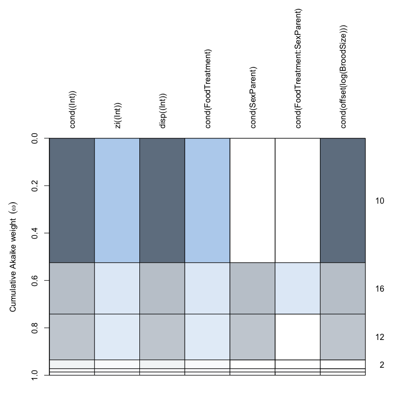

```r
op <- par(mar=c(2,5,14,3))
plot(owls_nb1_dredge)
```

```r
par(op) ## restore graphics parameters
```

Model averaging:

```r
model.avg(owls_nb1_dredge)
```

```
##
## Call:
## model.avg(object = owls_nb1_dredge)
##
## Component models:
## '14'     '1234'   '124'    '1'      '123'    '12'     '4'      '(Null)'
## '24'     '2'
##
## Coefficients:
##        cond((Int)) cond(FoodTreatment1) zi((Int)) cond(SexParent1)
## full     0.5183099             0.353877 -2.079432     -0.009556203
## subset   0.5183099             0.353877 -2.079432     -0.021827791
##        cond(FoodTreatment1:SexParent1)
## full                        0.01569108
## subset                      0.06797533
```

#### issues

- may not work for Beta models because the `$family` component (“beta”) is not identical to the name of the family function (`beta_family()`)? (Kamil Bartoń, pers. comm.)

### multcomp

Multiple comparisons and *post hoc* tests.

```r
glht_glmmTMB <- function (model, ..., component="cond") {
    glht(model, ...,
         coef. = function(x) fixef(x)[[component]],
         vcov. = function(x) vcov(x)[[component]],
         df = NULL)
}
modelparm.glmmTMB <- function (model, coef. = function(x) fixef(x)[[component]],
                               vcov. = function(x) vcov(x)[[component]],
                               df = NULL, component="cond", ...) {
    multcomp:::modelparm.default(model, coef. = coef., vcov. = vcov.,
                        df = df, ...)
}
```

```r
g1 <- glht(cbpp_b1, linfct = mcp(period = "Tukey"))
summary(g1)
```

```
##
##   Simultaneous Tests for General Linear Hypotheses
##
## Multiple Comparisons of Means: Tukey Contrasts
##
##
## Fit: glmmTMB(formula = incidence/size ~ period + (1 | herd), data = cbpp,
##     family = binomial, weights = size, ziformula = ~0, dispformula = ~1)
##
## Linear Hypotheses:
##            Estimate Std. Error z value Pr(>|z|)
## 2 - 1 == 0  -0.9923     0.3066  -3.236  0.00635 **
## 3 - 1 == 0  -1.1287     0.3266  -3.455  0.00283 **
## 4 - 1 == 0  -1.5803     0.4274  -3.697  0.00106 **
## 3 - 2 == 0  -0.1363     0.3807  -0.358  0.98368
## 4 - 2 == 0  -0.5880     0.4703  -1.250  0.58571
## 4 - 3 == 0  -0.4516     0.4843  -0.933  0.78116
## ---
## Signif. codes:  0 '***' 0.001 '**' 0.01 '*' 0.05 '.' 0.1 ' ' 1
## (Adjusted p values reported -- single-step method)
```

### broom etc.

The `broom`, `broom.mixed` packages are designed to extract information from a broad range of models in a convenient (tidy) format; the `dotwhisker` package builds on this platform to draw elegant coefficient plots.

```r
(t1 <- broom.mixed::tidy(owls_nb1, conf.int = TRUE))
if (packageVersion("dotwhisker")>"0.4.1") {
    ## to get this version (which fixes various dotwhisker problems)
    ## use devtools::install_github("bbolker/broom.mixed") or
    ## wait for pull request acceptance/submission to CRAN/etc.
    dwplot(owls_nb1)+geom_vline(xintercept=0,lty=2)
} else {
    owls_nb1$coefficients <- TRUE  ## hack!
    dwplot(owls_nb1,by_2sd=FALSE)+geom_vline(xintercept=0,lty=2)
}
```

[output not shown]

#### issues

(these are more general `dwplot` issues)

- use black rather than color(1) when there’s only a single model, i.e. only add `aes(colour=model)` conditionally?
- draw points even if std err / confint are `NA` (draw `geom_point()` as well as `geom_pointrange()`? need to apply all aesthetics, dodging, etc. to both …)
- for `glmmTMB` models, allow labeling by component? or should this be done by manipulating the tidied frame first? (i.e. `tidy(.) %>% tidyr::unite(term,c(component,term))`)

## to do

- add: `texreg` (regression tables)? `sjPlot` ? `memisc`, `huxtable`, … ?